# Math7340 HW10

Chengbo Gu

### Problem 1 (20 points) Preprocessing a data set

##### Install the “ArrayExpress” package from Bioconductor. Load the yeast microarray data using R commands:

##### yeast.raw = ArrayExpress(‘E-MEXP-1551’)

##### (a) Preprocess the raw data set into an expression data set using: the “mas” background correction method, the “quantiles” normalization method, “pmonly” pm correction method and “medianpolish” summary method. Give the R command here for doing this task.

```r
library(ArrayExpress)
library(affy)
```

```r
yeast.raw <-  ReadAffy(celfile.path= 'E:/yeast' )
eset <- expresso(yeast.raw,
                 bgcorrect.method="mas",
                 normalize.method="quantiles",
                 pmcorrect.method="pmonly",
                 summary.method="medianpolish")
```

##### (b) Print out the mean expression values for the first five genes across all samples.

```r
firstFive <- exprs(eset)[1:5,]
means <- apply(firstFive, 1, mean)
means
```

```
## 1769308_at 1769309_at 1769310_at 1769311_at 1769312_at
##   8.936128   5.666040   5.650467  11.380948   9.752480
```

##### (c) How many genes and how many samples are in the preprocessed expression data set?

```r
dim(eset)
```

```
## Features  Samples
##    10928       30
```

There are 10928 genes and 30 samples in the preprocessed expression data set.

### Problem 2 (30 points) Searching Annotations

##### (a) What is the annotation package for the yeast data set in question 1?

##### Install the annotation package from Bioconductor.

```r
anno <- annotation(yeast.raw)
anno
```

```
## [1] "yeast2"
```

```r
# db <- paste(anno, ".db", sep="")
# source("https://bioconductor.org/biocLite.R")
# biocLite(db)
```

The annotation package for the yeast data set is “yeast2”.

##### (b) Search the 1769308_at gene GO numbers related to Molecular Function (MF). How many GO numbers do you get?

```r
library(yeast2.db)
library(annotate)
```

```r
go1769308 <- get("1769308_at", env = yeast2GO)
gonr <- getOntology(go1769308, "MF")
gonr
```

```
## [1] "GO:0003824" "GO:0016616" "GO:0016853" "GO:0016491" "GO:0016829"
## [6] "GO:0004300" "GO:0003857"
```

```r
length(gonr)
```

```
## [1] 7
```

There are 7 GO numbers.

##### (c) Find the GO parents of the GO IDs in part (b). How many GO parents are there?

```r
library(GO.db)
```

```r
gP <- getGOParents(gonr)
pa <- sapply(gP, function(x) x$Parents)
length(unique(pa))
```

```
## [1] 5
```

There are 5 GO parents.

##### (d) Find the GO children of the GO IDs in part (b). How many GO children are there?

```r
gC <- getGOChildren(gonr)
ch <- sapply(gC, function(x) x$Children)
length(unique(unlist(ch)))
```

```
## [1] 434
```

There are 434 GO children.

### Problem 3 (30 points) Gene filtering on B-cell ALL patients

##### We work with the patients in stages “B2”,“B3”.

##### (a) We look for genes expressed differently in stages B2 and B3. Use genefilter to program the Wilcoxon test and the Welch t-test separately for each gene. For each test, we select the genes with p-value<0.001. To save computational time, we set exact=F in the Wilcoxon test function.

```r
library(genefilter)
library(ALL)
```

```r
data(ALL)


patientB2 <- factor(ALL$BT %in% c("B2"))
patientB3 <- factor(ALL$BT %in% c("B3"))
wilcox <- function(x) ( wilcox.test (x[patientB2 == TRUE], x[patientB3 == TRUE],
                                     paired = F, exact = F)$p.value < 0.001 )

selwilcox <- genefilter(exprs(ALL), filterfun(wilcox))

welch <- function(x) ( t.test(x[patientB2 == TRUE], x[patientB3 == TRUE],
                              paired = F) $p.value < 0.001 )

selwelch <- genefilter(exprs(ALL), filterfun(welch))
```

##### (b) Compute a Venn diagram for the Wilcoxon test and the t-test, and plot it.

```r
library(limma)
```

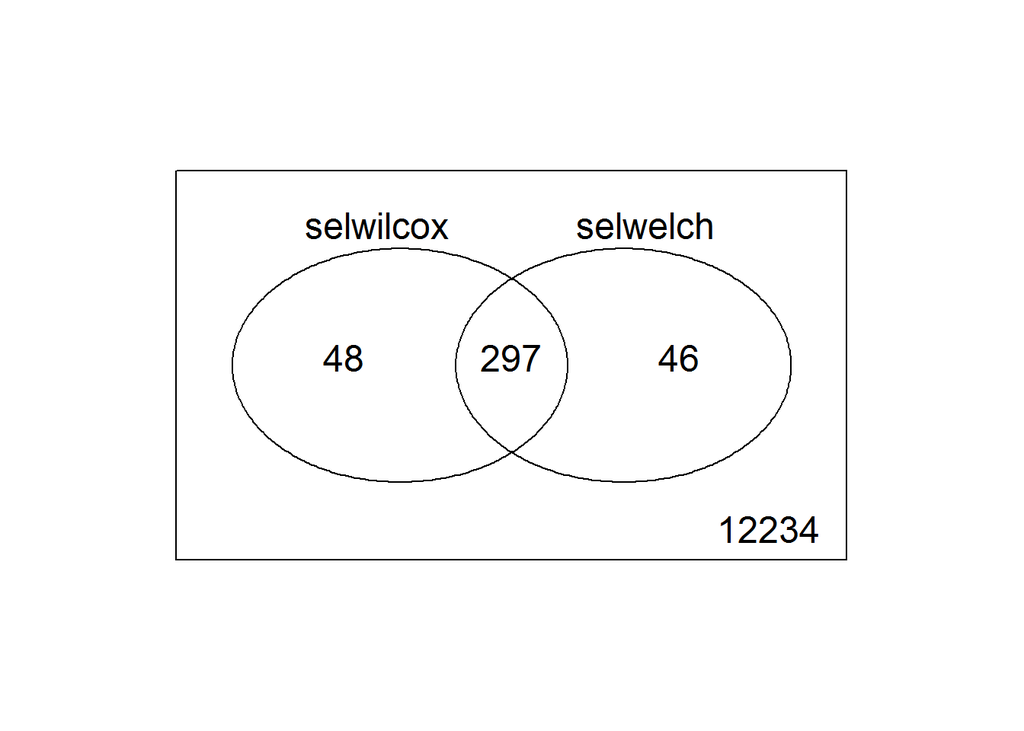

```r
x <- apply(cbind(selwilcox, selwelch), 2, as.integer)
vc <- vennCounts(x, include = "both")
vennDiagram(vc)
```

##### (c) How many pass the Wilcoxon filter? How many passes both filters?

```r
ALLwilcoxon <- ALL[selwilcox,]
nrow(exprs(ALLwilcoxon))
```

```
## [1] 345
```

```r
ALLboth <- ALL[selwilcox & selwelch,]
nrow(exprs(ALLboth))
```

```
## [1] 297
```

We can infer from both the venn diagram and the commands above. 345 genes pass the Wilcoxon filter. 297 genes pass both filters.

##### (d) What is the annotation package for the ALL data set? Find the GO numbers for “oncogene”.

```r
library(annotate)
```

```r
annotation(ALL)
```

```
## [1] "hgu95av2"
```

The annotation package for the ALL data set is “hgu95av2”.

```r
library(GO.db)
library(hgu95av2.db)
```

```r
GOTerm2Tag <- function(term) {
                GTL <- eapply(GOTERM, function(x) {grep(term, x@Term, value=TRUE)})
                Gl <- sapply(GTL, length)
                names(GTL[Gl>0])}
GOTerm2Tag("oncogene")
```

```
## [1] "GO:0090402"
```

The GO number for “oncogene” is “GO:0090402”.

##### (e) How many genes passing the filters in (a) are oncogenes?

```r
tran <- hgu95av2GO2ALLPROBES$"GO:0090402"
inboth <- tran %in% row.names(exprs(ALLboth))
ALLtran <- ALLboth[tran[inboth],]
dim(ALLtran)
```

```
## Features  Samples
##        0      128
```

There is no such gene.

### Problem 4 (20 points)

##### Stages of B-cell ALL in the ALL data. Use the limma package to answer the questions below.

##### (a) Select the persons with B-cell leukemia which are in stage B1, B2, and B3.

```r
library(limma)
library(ALL)
```

```r
data(ALL)
allB <- ALL[, which(ALL$BT %in% c("B1", "B2", "B3"))]
```

##### (b) Use the linear model to test the hypothesis of all zero group means. Use “topTable()” to report the top five genes with nonzero means in B3 group.

```r
design.ma <- model.matrix(~0 + factor(allB$BT))
colnames(design.ma) <- c("B1", "B2", "B3")
fit <- lmFit(allB, design.ma)
fit <- eBayes(fit)
print( topTable(fit, coef=3, number=5, adjust.method="fdr"), digits=4)
```

```
##                 logFC AveExpr     t    P.Value  adj.P.Val     B
## AFFX-hum_alu_at 13.61   13.53 355.6 5.059e-127 6.387e-123 270.8
## 32466_at        12.71   12.71 316.7 4.247e-123 2.681e-119 263.9
## 31962_at        13.05   13.09 307.1 4.695e-122 1.976e-118 262.0
## 32748_at        12.15   12.12 302.8 1.407e-121 4.406e-118 261.2
## 35278_at        12.52   12.48 302.0 1.745e-121 4.406e-118 261.0
```

##### (c) Use two contrasts to perform analysis of variance to test the null hypothesis of equal group means. Do this with a false discovery rate of 0.01. How many differentially expressed genes are found? Use “topTable()” to report the top five genes that express differently among the three groups.

```r
cont.ma <- makeContrasts(B1-B2,B2-B3, levels=factor(allB$BT))
fit1 <- contrasts.fit(fit, cont.ma)
fit1 <- eBayes(fit1)
dim(topTable(fit1, number=Inf, p.value=0.01, adjust.method="fdr"))
```

```
## [1] 314   6
```

There are 314 genes that are expressed differentially.

```r
print( topTable(fit1, number=5, adjust.method="fdr"), digits=4)
```

```
##          B1...B2  B2...B3 AveExpr     F   P.Value adj.P.Val
## 1389_at  -1.7852 -0.74038   9.678 49.15 1.532e-14 1.934e-10
## 1914_at   2.0976  0.35648   4.693 42.20 3.785e-13 2.389e-09
## 33358_at  1.4890 -0.20733   5.214 29.52 2.837e-10 1.194e-06
## 38555_at  0.8058  0.62321   6.124 25.93 2.322e-09 7.329e-06
## 40763_at  1.5921 -0.01192   3.220 23.08 1.337e-08 2.758e-05
```